# Njoroge et al 2023 meta-analysis

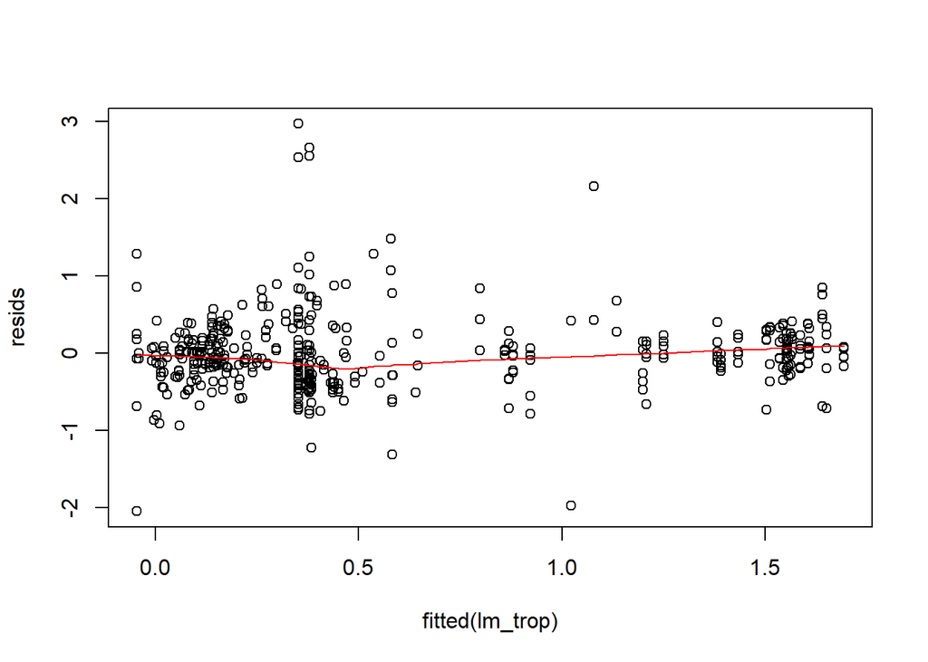

```r
resids <- resid(lm_trop, type='pearson')
plot(resids~fitted(lm_trop))
lines(lowess(resids~fitted(lm_trop)), col='red')
```

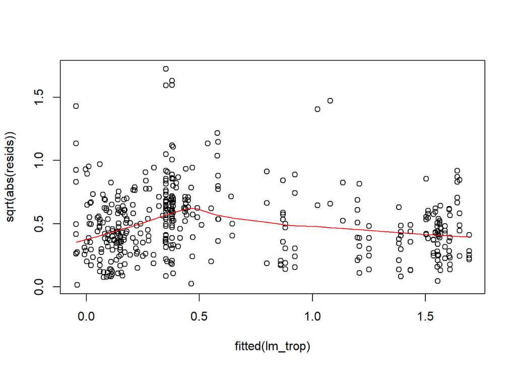

```r
plot(sqrt(abs(resids))~ fitted(lm_trop))
lines(lowess(sqrt(abs(resids))~

               fitted(lm_trop)), col='red')
```

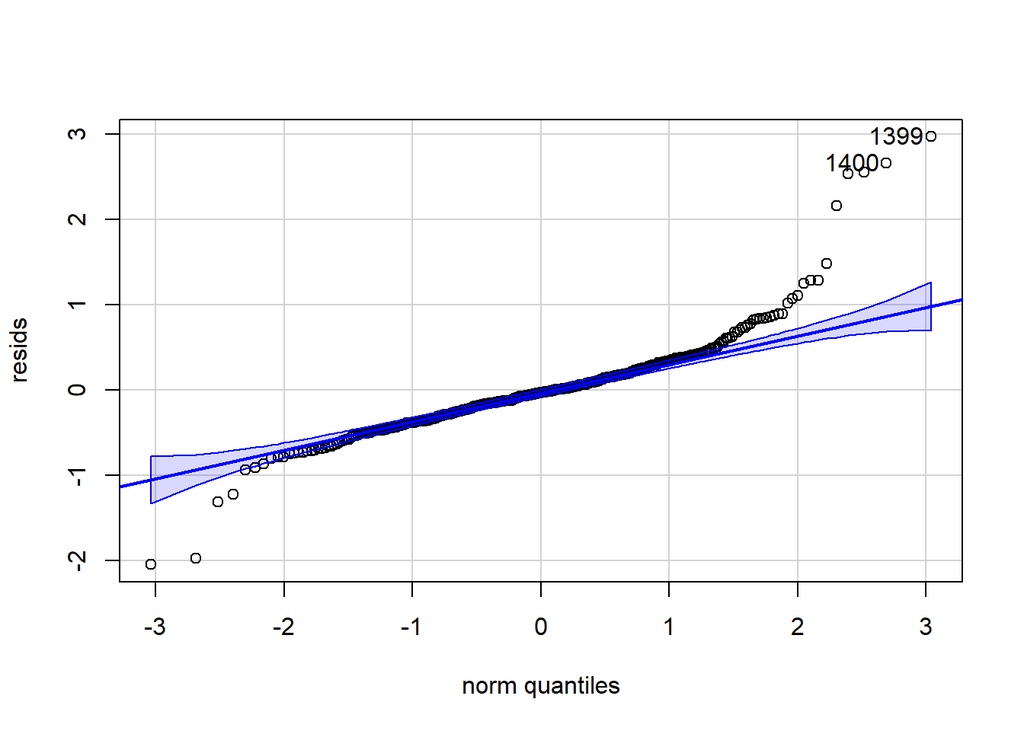

```
## 1399 1400
##  413  414
```

```r
library(car)

library(arm)
qqPlot(resids)
```

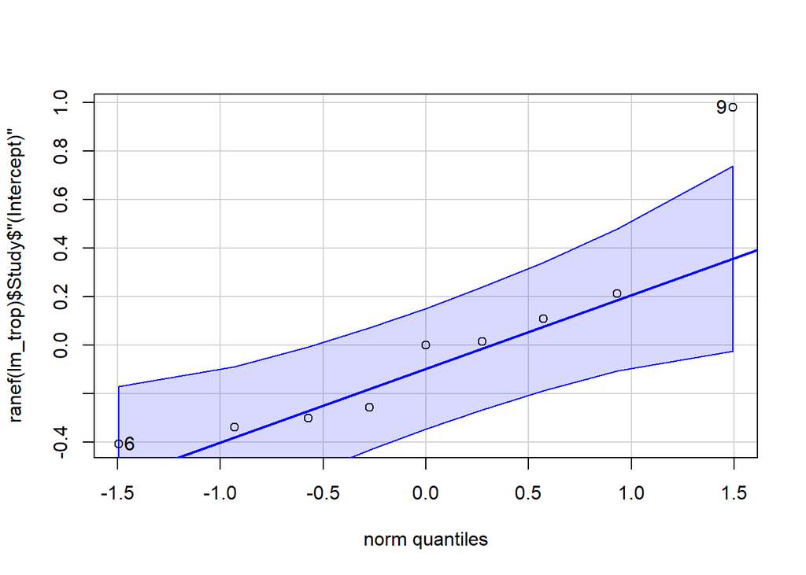

```
## [1] 9 6
```

```r
qqPlot(ranef(lm_trop)$Study$'(Intercept)')
```

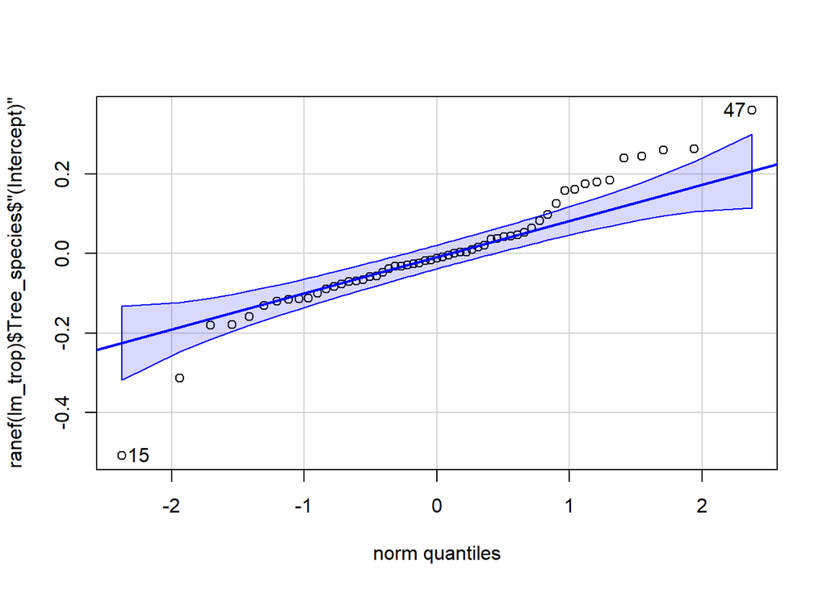

```
## [1] 15 47
```

```r
qqPlot(ranef(lm_trop)$Tree_species$'(Intercept)')
```

```r
lm_temp<- lmer(yi~ Study_duration_months + ( 1 | Study/Tree_species), data= temperate)
summary(lm_temp)
```

```
## Linear mixed model fit by REML. t-tests use Satterthwaite's method [
## lmerModLmerTest]
## Formula: yi ~ Study_duration_months + (1 | Study/Tree_species)
##    Data: temperate
##
## REML criterion at convergence: 1263.5
##
## Scaled residuals:
##     Min      1Q  Median      3Q     Max
## -3.9647 -0.4057 -0.0450  0.3257  5.5623
##
## Random effects:
##  Groups             Name        Variance Std.Dev.
##  Tree_species:Study (Intercept) 0.1633   0.4042
##  Study              (Intercept) 0.1821   0.4268
##  Residual                       0.2015   0.4489
## Number of obs: 872, groups:  Tree_species:Study, 101; Study, 13
##
## Fixed effects:
##                         Estimate Std. Error         df t value Pr(>|t|)
## (Intercept)             0.515862   0.160700   9.254753   3.210   0.0103 *
## Study_duration_months  -0.004158   0.001671 812.619381  -2.489   0.0130 *
## ---
## Signif. codes:  0 '***' 0.001 '**' 0.01 '*' 0.05 '.' 0.1 ' ' 1
##
## Correlation of Fixed Effects:
##             (Intr)
## Stdy_drtn_m -0.210
```

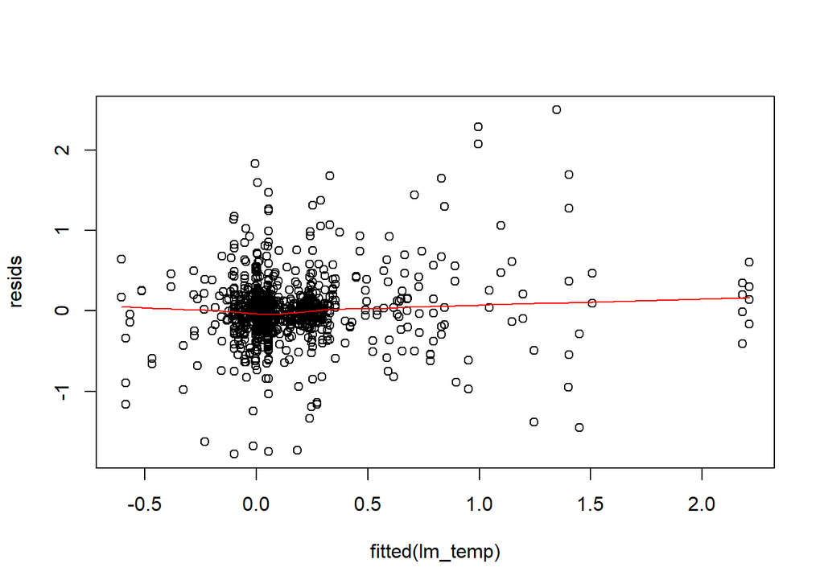

```r
resids <- resid(lm_temp, type='pearson')
plot(resids~fitted(lm_temp))
lines(lowess(resids~fitted(lm_temp)), col='red')
```

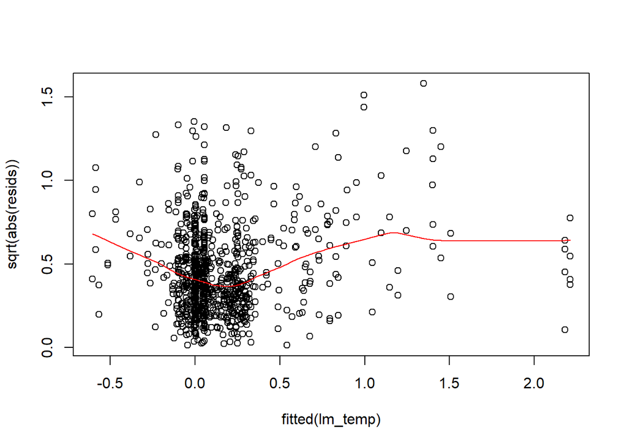

```r
plot(sqrt(abs(resids))~ fitted(lm_temp))
lines(lowess(sqrt(abs(resids))~

               fitted(lm_temp)), col='red')
```

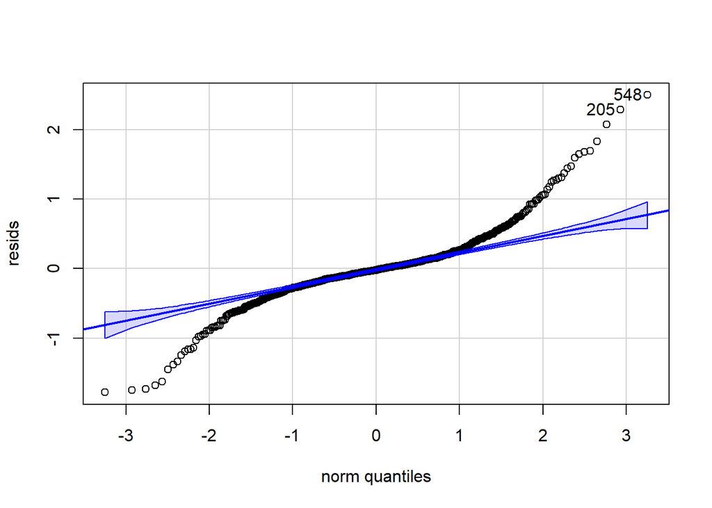

```
## 548 205
## 280  65
```

```r
library(car)

library(arm)
qqPlot(resids)# not looking good
```

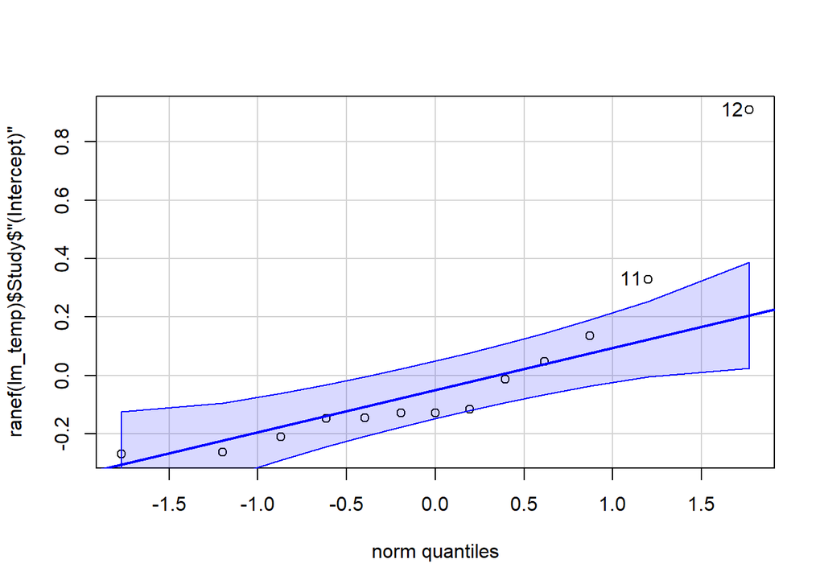

```
## [1] 12 11
```

```r
qqPlot(ranef(lm_temp)$Study$'(Intercept)')
```

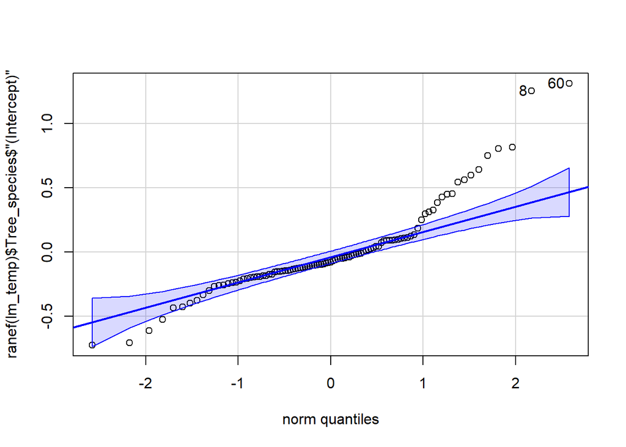

```
## [1] 60  8
```

```r
qqPlot(ranef(lm_temp)$Tree_species$'(Intercept)')
```

```r
lm_cont<- lmer(yi~ Study_duration_months + ( 1 | Study/Tree_species), data= continental)
```

```
## boundary (singular) fit: see help('isSingular')
```

```r
summary(lm_cont)
```

```
## Linear mixed model fit by REML. t-tests use Satterthwaite's method [
## lmerModLmerTest]
## Formula: yi ~ Study_duration_months + (1 | Study/Tree_species)
##    Data: continental
##
## REML criterion at convergence: 273.9
##
## Scaled residuals:
##     Min      1Q  Median      3Q     Max
## -3.9228 -0.3014  0.0835  0.4631  2.2304
##
## Random effects:
##  Groups             Name        Variance Std.Dev.
##  Tree_species:Study (Intercept) 0.06674  0.2583
##  Study              (Intercept) 0.00000  0.0000
##  Residual                       0.58950  0.7678
## Number of obs: 111, groups:  Tree_species:Study, 21; Study, 2
##
## Fixed effects:
##                         Estimate Std. Error         df t value Pr(>|t|)
## (Intercept)            -0.224497   0.240682  73.691374  -0.933    0.354
## Study_duration_months   0.003332   0.009101 102.125842   0.366    0.715
##
## Correlation of Fixed Effects:
##             (Intr)
## Stdy_drtn_m -0.915
## optimizer (nloptwrap) convergence code: 0 (OK)
## boundary (singular) fit: see help('isSingular')
```

```r
wood_meta_fauna$climate_zone<- relevel(wood_meta_fauna$climate_zone, ref= "Tropical")
lm_all<- lmer(yi~ Study_duration_months*climate_zone + ( 1 | Study/Tree_species), data= wood_meta_fauna)
summary(lm_all)
```

```
## Linear mixed model fit by REML. t-tests use Satterthwaite's method [
## lmerModLmerTest]
## Formula: yi ~ Study_duration_months * climate_zone + (1 | Study/Tree_species)
##    Data: wood_meta_fauna
##
## REML criterion at convergence: 2508.2
##
## Scaled residuals:
##     Min      1Q  Median      3Q     Max
## -5.4848 -0.4003 -0.0618  0.3177  5.7108
##
## Random effects:
##  Groups             Name        Variance Std.Dev.
##  Tree_species:Study (Intercept) 0.08001  0.2829
##  Study              (Intercept) 0.24530  0.4953
##  Residual                       0.29054  0.5390
## Number of obs: 1427, groups:  Tree_species:Study, 169; Study, 20
##
## Fixed effects:
##                                                 Estimate Std. Error         df
## (Intercept)                                    5.773e-01  1.457e-01  2.814e+01
## Study_duration_months                         -5.168e-04  3.980e-03  1.415e+03
## climate_zoneArid                               1.315e+00  2.537e-01  1.271e+03
## climate_zoneTemperate                         -1.024e-01  8.775e-02  1.406e+03
## climate_zoneContinental                       -4.901e-01  1.729e-01  1.409e+03
## Study_duration_months:climate_zoneArid        -4.809e-02  1.488e-02  1.276e+03
## Study_duration_months:climate_zoneTemperate   -2.848e-03  4.432e-03  1.418e+03
## Study_duration_months:climate_zoneContinental  1.352e-03  7.312e-03  1.412e+03
##                                               t value Pr(>|t|)
## (Intercept)                                     3.961 0.000463 ***
## Study_duration_months                          -0.130 0.896701
## climate_zoneArid                                5.185 2.51e-07 ***
## climate_zoneTemperate                          -1.167 0.243485
## climate_zoneContinental                        -2.835 0.004647 **
## Study_duration_months:climate_zoneArid         -3.231 0.001266 **
## Study_duration_months:climate_zoneTemperate    -0.643 0.520619
## Study_duration_months:climate_zoneContinental   0.185 0.853321
## ---
## Signif. codes:  0 '***' 0.001 '**' 0.01 '*' 0.05 '.' 0.1 ' ' 1
##
## Correlation of Fixed Effects:
##             (Intr) Stdy__ clmt_A clmt_T clmt_C S__:_A S__:_T
## Stdy_drtn_m -0.409
## climt_znArd -0.118  0.219
## clmt_znTmpr -0.389  0.663  0.225
## clmt_znCntn -0.180  0.338  0.114  0.337
## Stdy_dr_:_A  0.109 -0.267 -0.882 -0.177 -0.090
## Stdy_dr_:_T  0.377 -0.895 -0.197 -0.821 -0.301  0.239
## Stdy_dr_:_C  0.216 -0.532 -0.122 -0.352 -0.877  0.142  0.479
```

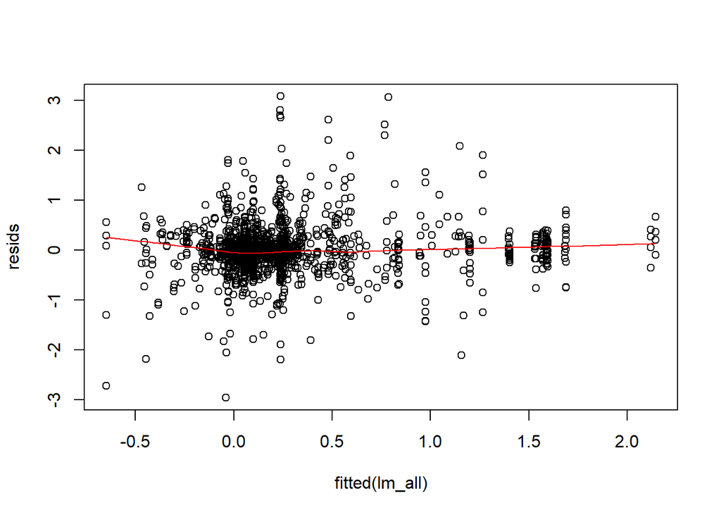

```r
resids <- resid(lm_all, type='pearson')
plot(resids~fitted(lm_all))
lines(lowess(resids~fitted(lm_all)), col='red')
```

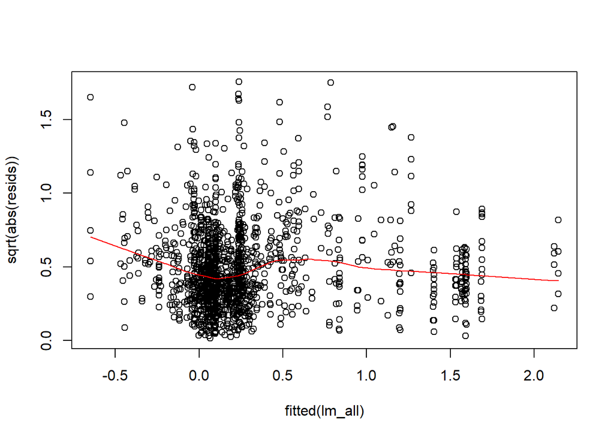

```r
plot(sqrt(abs(resids))~ fitted(lm_all))
lines(lowess(sqrt(abs(resids))~

               fitted(lm_all)), col='red')
```

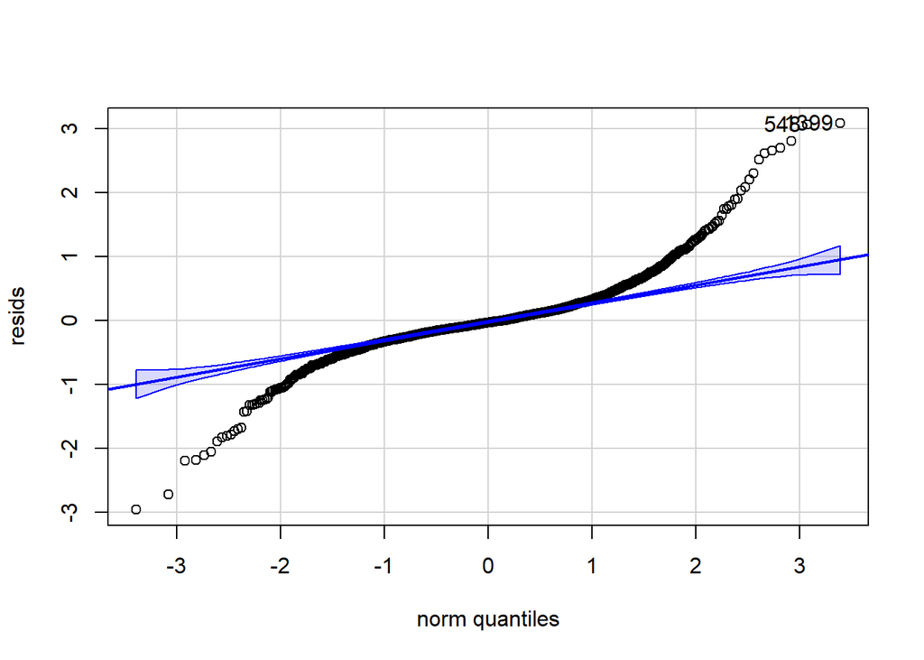

```
## 1399  548
## 1397  547
```

```r
library(car)

library(arm)
qqPlot(resids)# not looking good
```

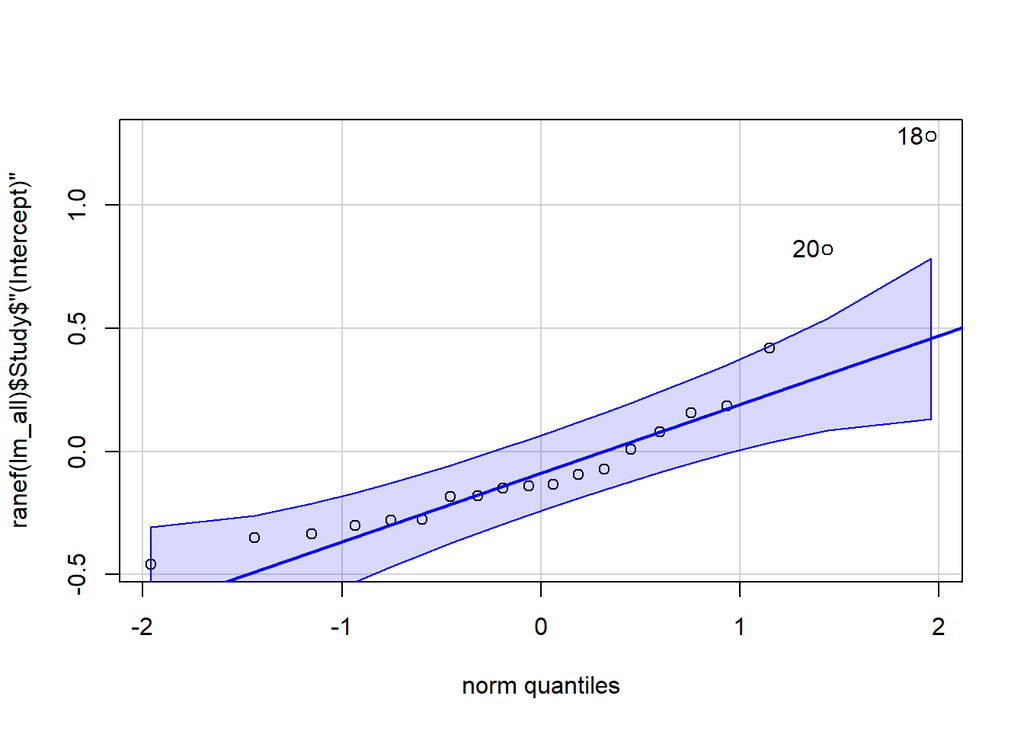

```
## [1] 18 20
```

```r
qqPlot(ranef(lm_all)$Study$'(Intercept)')
```

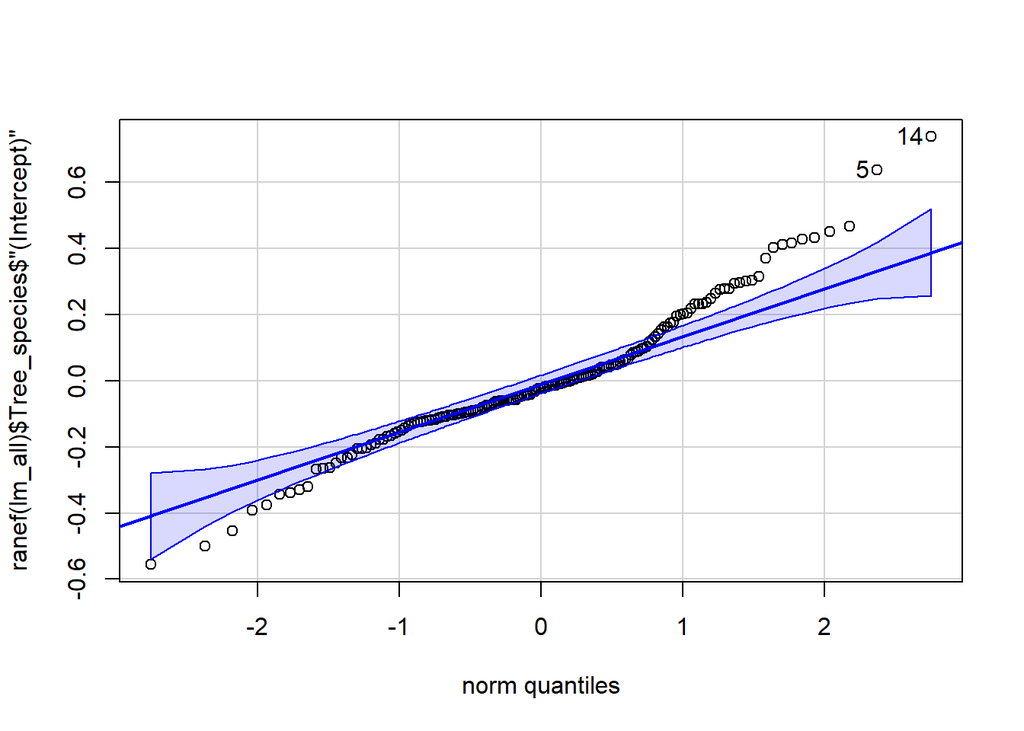

```
## [1] 14  5
```

```r
qqPlot(ranef(lm_all)$Tree_species$'(Intercept)')
```

```r
#wood_meta_fauna$climatic_region<- relevel(wood_meta_fauna$climatic_region, ref= "Temperate")
lm_trop<- lmer(yi~ Study_duration_months + ( 1 | Study/Tree_species), data= tropical)
lm_arid<- lm(yi~ Study_duration_months, data= arid)
lm_temp<- lm(yi~ Study_duration_months, data= temperate)
lm_cont<- lm(yi~ Study_duration_months, data= continental)
#summary(lm_trop)
summary(lm_trop)
```

```
## Linear mixed model fit by REML. t-tests use Satterthwaite's method [
## lmerModLmerTest]
## Formula: yi ~ Study_duration_months + (1 | Study/Tree_species)
##    Data: tropical
##
## REML criterion at convergence: 710.2
##
## Scaled residuals:
##     Min      1Q  Median      3Q     Max
## -3.9394 -0.5044 -0.0654  0.3662  5.7114
##
## Random effects:
##  Groups             Name        Variance Std.Dev.
##  Tree_species:Study (Intercept) 0.04883  0.2210
##  Study              (Intercept) 0.22405  0.4733
##  Residual                       0.26963  0.5193
## Number of obs: 420, groups:  Tree_species:Study, 57; Study, 9
##
## Fixed effects:
##                        Estimate Std. Error        df t value Pr(>|t|)
## (Intercept)           3.952e-01  1.854e-01 1.135e+01   2.132   0.0557 .
## Study_duration_months 4.709e-03  3.955e-03 4.179e+02   1.191   0.2345
## ---
## Signif. codes:  0 '***' 0.001 '**' 0.01 '*' 0.05 '.' 0.1 ' ' 1
##
## Correlation of Fixed Effects:
##             (Intr)
## Stdy_drtn_m -0.333
```

```r
summary(lm_arid)
```

```
##
## Call:
## lm(formula = yi ~ Study_duration_months, data = arid)
##
## Residuals:
##     Min      1Q  Median      3Q     Max
## -1.8015 -0.9973 -0.1792  0.9171  2.0304
##
## Coefficients:
##                       Estimate Std. Error t value Pr(>|t|)
## (Intercept)            1.55695    0.53649   2.902  0.00826 **
## Study_duration_months -0.04860    0.03163  -1.536  0.13869
## ---
## Signif. codes:  0 '***' 0.001 '**' 0.01 '*' 0.05 '.' 0.1 ' ' 1
##
## Residual standard error: 1.189 on 22 degrees of freedom
## Multiple R-squared:  0.09691,    Adjusted R-squared:  0.05586
## F-statistic: 2.361 on 1 and 22 DF,  p-value: 0.1387
```

```r
summary(lm_temp)
```

```
##
## Call:
## lm(formula = yi ~ Study_duration_months, data = temperate)
##
## Residuals:
##     Min      1Q  Median      3Q     Max
## -2.0676 -0.2774 -0.0751  0.1374  3.7477
##
## Coefficients:
##                        Estimate Std. Error t value Pr(>|t|)
## (Intercept)            0.256605   0.046137   5.562 3.55e-08 ***
## Study_duration_months -0.004341   0.001905  -2.279   0.0229 *
## ---
## Signif. codes:  0 '***' 0.001 '**' 0.01 '*' 0.05 '.' 0.1 ' ' 1
##
## Residual standard error: 0.581 on 870 degrees of freedom
## Multiple R-squared:  0.005936,   Adjusted R-squared:  0.004793
## F-statistic: 5.195 on 1 and 870 DF,  p-value: 0.02289
```

```r
summary(lm_cont)
```

```
##
## Call:
## lm(formula = yi ~ Study_duration_months, data = continental)
##
## Residuals:
##     Min      1Q  Median      3Q     Max
## -3.2188 -0.2652  0.0753  0.3758  1.9225
##
## Coefficients:
##                         Estimate Std. Error t value Pr(>|t|)
## (Intercept)           -0.1705175  0.2229550  -0.765    0.446
## Study_duration_months  0.0008589  0.0087738   0.098    0.922
##
## Residual standard error: 0.807 on 109 degrees of freedom
## Multiple R-squared:  8.792e-05,  Adjusted R-squared:  -0.009086
## F-statistic: 0.009584 on 1 and 109 DF,  p-value: 0.9222
```

```r
anova(lm_trop)
```

```
## Type III Analysis of Variance Table with Satterthwaite's method
##                        Sum Sq Mean Sq NumDF  DenDF F value Pr(>F)
## Study_duration_months 0.38224 0.38224     1 417.93  1.4176 0.2345
```

```r
anova(lm_arid)
```

```
## Analysis of Variance Table
##
## Response: yi
##                       Df Sum Sq Mean Sq F value Pr(>F)
## Study_duration_months  1  3.337  3.3370  2.3607 0.1387
## Residuals             22 31.099  1.4136
```

```r
anova(lm_temp)
```

```
## Analysis of Variance Table
##
## Response: yi
##                        Df  Sum Sq Mean Sq F value  Pr(>F)
## Study_duration_months   1   1.753 1.75343  5.1949 0.02289 *
## Residuals             870 293.648 0.33753
## ---
## Signif. codes:  0 '***' 0.001 '**' 0.01 '*' 0.05 '.' 0.1 ' ' 1
```

```r
anova(lm_cont)
```

```
## Analysis of Variance Table
##
## Response: yi
##                        Df Sum Sq Mean Sq F value Pr(>F)
## Study_duration_months   1  0.006 0.00624  0.0096 0.9222
## Residuals             109 70.978 0.65117
```

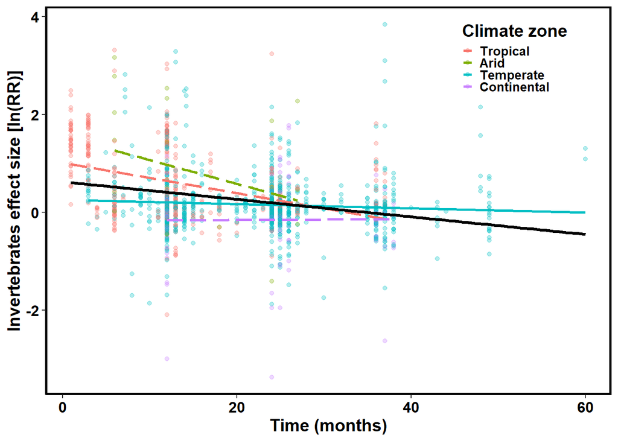

```r
region_duration<- ggplot()+
  geom_point(data=wood_meta_fauna, aes(x= Study_duration_months, y= yi, colour=climate_zone ), size=1.5,alpha=0.3)+
  geom_smooth(data=wood_meta_fauna,method = "lm",se=FALSE,aes(x= Study_duration_months, y= yi, colour=climate_zone,linetype=climate_zone), alpha= 0.1)+
  scale_linetype_manual (values = c("Tropical" = 5, "Arid" = 5, "Temperate" = 1,"Continental" = 5 ))+
  geom_smooth(data=wood_meta_fauna,method = "lm",se=FALSE, color = "black", aes(x= Study_duration_months, y= yi),size=1.2)+
  scale_linetype_manual (values = c("Tropical" = 5, "Arid" = 5, "Temperate" = 1,"Continental" = 5 ))+
  labs(colour='Climate zone') +labs(x='Time (months)', y="Invertebrates effect size [ln(RR)]")+

  guides(linetype=FALSE)+theme(text = element_text(size = 14,face="bold"), panel.background = element_blank(),
                                                   panel.grid.major = element_blank(),
                                                   panel.grid.minor = element_blank(),
                                                   axis.line = element_line(colour = "black"),
                                                   panel.border = element_rect(colour = "black", fill=NA, size=1.5)) +  theme(axis.text = element_text(family = "palatino", colour = "black", size = (12)))+ theme(legend.position = c(0.83,0.87),
        legend.text=element_text(size=10),
        legend.background = element_blank(),
        legend.key.width=unit(0.3,"cm"),
        legend.key.height=unit(0.3,"cm"))
region_duration
```

```r
ggsave(filename="Figure 5 Effects of incubation duration on invertebrate effect.png", plot=region_duration, device="png",
     path=path, height=4, width=5, units="in", dpi=500)
```

# 10 Multivariate meta-analysis

In the above section, we used random effect model to estimate the overall effect size. We are interested in knowing the actual effect of invertebrates effect on wood decomposition globally and therefore we have to put into consideration that WD species identity have an effect on the invertebrates effect. In this section we therefore consider species as a random effect in the estimation of the overall mean. Species is nested within studies. To include the random effect we will use the **rma.mv** function from metafor package.

## 10.1 overall effect size when considering species as a random factor

```r
wood_meta_fauna$Study<-as.factor(wood_meta_fauna$Study)
random_m2 <- rma.mv(yi, vi, random = ~ 1 | Study/Tree_species, data = wood_meta_fauna)
summary(random_m2)
```

```
##
## Multivariate Meta-Analysis Model (k = 1427; method: REML)
##
##       logLik      Deviance           AIC           BIC          AICc
## -162858.5668   325717.1336   325723.1336   325738.9215   325723.1505
##
## Variance Components:
##
##             estim    sqrt  nlvls  fixed              factor
## sigma^2.1  0.3958  0.6291     20     no               Study
## sigma^2.2  0.0519  0.2278    169     no  Study/Tree_species
##
## Test for Heterogeneity:
## Q(df = 1426) = 585731.9656, p-val < .0001
##
## Model Results:
##
## estimate      se    zval    pval   ci.lb   ci.ub
##   0.3392  0.1477  2.2969  0.0216  0.0498  0.6287  *
##
## ---
## Signif. codes:  0 '***' 0.001 '**' 0.01 '*' 0.05 '.' 0.1 ' ' 1
```

```r
exp(0.3392)
```

```
## [1] 1.403824
```

Please note that this estimate is different from what we got in the rma model earlier without considering species as a random factor nested in different studies. For your information, initially it was around 29% but now its around 40%. We consider this new value to be the more plausible estimate.

Please note that we calculate the effect size of the subsets with rma.mv function it does not put the random factor into consideration and therefore the results are exactly the same as shown in the rma models.

http://www.metafor-project.org/doku.php/tips:rma.uni_vs_rma.mv

# 11 Multivariate Modeling

https://www.rdocumentation.org/packages/metafor/versions/2.4-0/topics/rma.mv Next we fix a model showing how overall effect size is influenced by other moderators while considering study and tree species as a random factor.

```r
mod1<- rma.mv(yi, vi, mods = ~climate_zone+ Study_duration_months+natural_wood_or_block+Clade+Bark_status_presence_or_absent+wood_diameter+Tmean+Precip, random = ~ 1 | Study/Tree_species, data=wood_meta_fauna)
summary(mod1)
```

```
##
## Multivariate Meta-Analysis Model (k = 1417; method: REML)
##
##       logLik      Deviance           AIC           BIC          AICc
## -141688.9045   283377.8090   283403.8090   283472.0395   283404.0704
##
## Variance Components:
##
##             estim    sqrt  nlvls  fixed              factor
## sigma^2.1  0.5304  0.7283     19     no               Study
## sigma^2.2  0.0516  0.2272    166     no  Study/Tree_species
##
## Test for Residual Heterogeneity:
## QE(df = 1406) = 308536.7838, p-val < .0001
##
## Test of Moderators (coefficients 2:11):
## QM(df = 10) = 40400.9568, p-val < .0001
##
## Model Results:
##
##                                        estimate      se      zval    pval
## intrcpt                                  0.0953  0.2489    0.3830  0.7017
## climate_zoneArid                         0.5631  0.0462   12.1912  <.0001
## climate_zoneTemperate                   -0.2126  0.0289   -7.3669  <.0001
## climate_zoneContinental                 -0.1061  0.0479   -2.2145  0.0268
## Study_duration_months                    0.0102  0.0001  199.4885  <.0001
## natural_wood_or_blocknatural            -0.1646  0.0978   -1.6834  0.0923
## Cladegymnosperm                          0.1632  0.0580    2.8128  0.0049
## Bark_status_presence_or_absentpresent   -0.0845  0.1327   -0.6370  0.5241
## wood_diameter                            0.0004  0.0027    0.1618  0.8715
## Tmean                                    0.0009  0.0001    6.0566  <.0001
## Precip                                   0.0000  0.0000    1.3318  0.1829
##                                          ci.lb    ci.ub
## intrcpt                                -0.3925   0.5832
## climate_zoneArid                        0.4726   0.6536  ***
## climate_zoneTemperate                  -0.2692  -0.1561  ***
## climate_zoneContinental                -0.2000  -0.0122    *
## Study_duration_months                   0.0101   0.0103  ***
## natural_wood_or_blocknatural           -0.3563   0.0270    .
## Cladegymnosperm                         0.0495   0.2769   **
## Bark_status_presence_or_absentpresent  -0.3447   0.1756
## wood_diameter                          -0.0048   0.0057
## Tmean                                   0.0006   0.0012  ***
## Precip                                 -0.0000   0.0000
##
## ---
## Signif. codes:  0 '***' 0.001 '**' 0.01 '*' 0.05 '.' 0.1 ' ' 1
```

## 11.1 Conduct model selection using glmulti

```r
#library(glmulti)
#library(metafor)
```

```r
#cor1 <- cor.test(wood_meta_fauna$Tmean, wood_meta_fauna$Precip,
 #               method = "pearson")
#cor1
```

```r
#dim(wood_meta_fauna)
#wood_meta_fauna2 <- wood_meta_fauna[!apply(wood_meta_fauna[,c( "Study_duration_months","Clade","natural_wood_or_block", "Bark_status_presence_or_absent","wood_diameter","Tmean", "Precip" )], 1, anyNA),]
#dim(wood_meta_fauna2)
```

Define a function that takes a model formula and a dataset as input and then fits a random or mixed-effects meta-regression model to the given data using maximum likelihood estimation:

```r
#rma.glmulti <- function (formula, data) {rma.mv (as.formula(paste(deparse(formula))), vi, random = ~ 1 | Study/Tree_species, verbose = #TRUE, control=list(rel.tol=1e-8),
 #                                                data=wood_meta_fauna2, method = "ML")}
```

https://stackoverflow.com/questions/46050023/metafor-coupled-with-glmulti-how-to-exclude-undesirable-interactions

Now we use **glmulti** function to select the best models explaining the variations in our effect size

```r
#res <- glmulti(yi ~Study_duration_months+Clade+Bark_status_presence_or_absent+natural_wood_or_block+wood_diameter+Tmean+Precip,data=wood_meta_fauna2,
 #              level=2, marginality=TRUE,fitfunction=rma.glmulti,method= "g", crit="aicc")
```

Brief summary of the results

```r
#BB<-plot(res, type="s")
#summary(res)
#eval(metafor:::.glmulti)
#coef(res)
```

```r
#print (res)
```

Plot of the AICc values for all the possible models

```r
#plot(res)
```

Here we look at the top models within a difference of 2 AIC

```r
#top <- weightable(res)
#top <- top[top$aicc <= min(top$aicc) + 2,]
#top
```

Examine the best model

```r
#summary(res@objects[[1]])
```

Multivariate Meta-Analysis Model (k = 1417; method: ML)

```
  logLik      Deviance           AIC           BIC          AICc
```

-139756.6127 280884.2861 279559.2254 279680.1202 279560.0179

Variance Components:

```
        estim    sqrt  nlvls  fixed              factor
```

sigma^2.1 4.5188 2.1257 19 no Study sigma^2.2 0.0471 0.2170 166 no Study/Tree_species

Test for Residual Heterogeneity: QE(df = 1396) = 309893.4714, p-val < .0001

Test of Moderators (coefficients 2:21): QM(df = 20) = 44296.8735, p-val < .0001

Signif. codes: 0 ‘**’ 0.001 ‘**’ 0.01 ‘’ 0.05 ‘.’ 0.1 ‘ ’ 1

# 12 Conclusion

This study investigated woody debris (WD) decomposition which is an important process in nutrient cycling within ecosystems. The results add to the current ecology knowledge by revealing that invertebrates contribute to WD decomposition and that their contribution varies with climate zone and species traits.